# Math 490 HW #8

Maxwell Levin

February 15, 2018

## Question 1.

#### Consider computing the definite integral $\small{I = \int_0^\pi sin(x^2)dx}$ using Monte Carlo methods.

#### a. Use Mathematica to compute the value of $\small{I}$ up to 10 decimal places.

We run the following code in Mathematica:

```
N[Integrate[Sin[x^2], {x, 0, Pi}], 11]
0.77265171269
```

#### b. Use Mathematica to compute the value of

$$\eta^2 = \int_0^\pi \left[sin(x^2)\right]^2dx - I^2$$

#### up to 10 decimal places.

We run the following code in Mathematica:

```
N[Integrate[Sin[x^2]^2, {x, 0, Pi}] - Integrate[Sin[x^2], {x, 0, Pi}]^2, 11]
0.72202590708
```

#### c. Construct a Monte Carlo estimator $\small{Z_N^{MC} = Z_N^{MC}(X_1, X_2, \dots, X_N)}$ with sample size $\small{N}$ for estimating $\small{I}$.

We construct the Monte Carlo Estimator:

$$Z_N^{MC} = \frac{\pi sin(x_1^2) + \pi sin(x_2^2) + \dots + \pi sin(x_N^2)}{N}$$

#### d. If sample size $\small{N = 4}$, what is the mean and standard deviation of the Monte Carlo estimator constucted in part (c)?

We know that our mean does not change with the sample size. That is,

$$E(Z_4^{MC}) = E(Z_1^{MC}) = I \approx 0.772.$$

Since we know that our standard deviation decreases by a factor of the square root of the sample size, we know that

$$SD(Z_4^{MC}) = \frac{1}{2}SD(Z_1^{MC}) = \frac{1}{2}\sqrt{Var{Z_1^{MC}}},$$
$$SD(Z_4^{MC}) = \frac{1}{2}\sigma,$$

where we get $\sigma^2$ numerically by

```
N[Integrate[Pi*Sin[x^2]^2, {x, 0, Pi}] - Integrate[Sin[x^2], {x, 0, Pi}]^2, 11]
3.5468221166
```

That is,

$$SD(Z_4^{MC}) \approx 0.942.$$

#### e. With sample size $\small{N = 4}$, use R to simulate 1024 Monte Carlo estimates of $\small{I}$. Make a histogram of those 1024 Monte Carlo estimates, and report the mean and the standard deviation of those 1024 estimates.

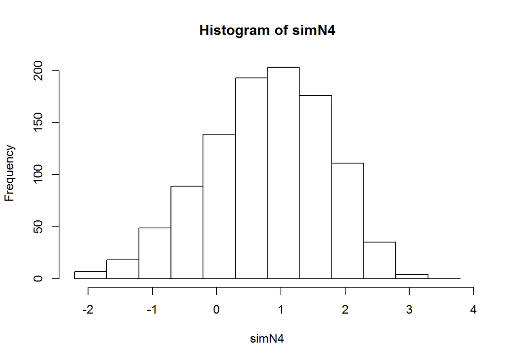

```r
clt = function(sam, rep) {
  obs = NULL
  for (i in 1:rep) {
    x = runif(sam, 0, pi)
    zbar = mean(pi*sin(x^2))
    obs = c(obs, zbar)
  }
  obs
}

simN4 = clt(4, 1024)
hist(simN4, breaks=seq(min(simN4), max(simN4)+1, 0.5), prob=F)
```

The mean of our simulation is:

```
[1] 0.769082
```

The standard deviation of our simulation is:

```
[1] 0.9414037
```

#### f. With sample size $\small{N = 36}$, use R to simulate 1024 Monte Carlo estimates of $\small{I}$. Make a histogram of those 1024 Monte Carlo estimates, and report the mean and the standard deviation of those 1024 estimates.

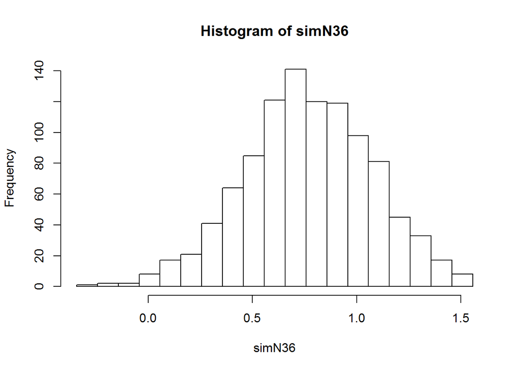

```r
simN36 = clt(36, 1024)
hist(simN36, breaks=seq(min(simN36), max(simN36)+0.1, 0.1), prob=F)
```

The mean is

```
[1] 0.7696945
```

The standard deviation of our simulation is

```
[1] 0.3069081
```